# Predictive_analytics

```python
#suppress warnings for a clean notebook just to moderate error messages
import warnings
warnings.filterwarnings('ignore')
```

```python
import pandas as pd
import numpy as np
import matplotlib.pyplot as plt
from sklearn.preprocessing import MinMaxScaler
import tensorflow as tf
from tensorflow import keras
from sklearn.model_selection import train_test_split
from sklearn.metrics import mean_squared_error, mean_absolute_error, r2_score


# Loading historical price data
# I had to clean the date column because the entries were wrongly set using microsoft excel
df = pd.read_csv(r'C:\Users\PC\Desktop\KIbe\sem 2\Unstructured data analytics & apps\jupkibe\data\cpi.csv')
df['Date'] = pd.to_datetime(df['Date'])
df.set_index('Date', inplace=True)
data = df['Kenya CPI'].values.reshape(-1, 1)
```

- CPI utilizes weighted averages, in our case a basket has been randomly selected
- A basket of goods and services that are commonly purchased by a typical household.
- Then these products and services commonly purchased by a typical household are averaged using varying levels of importance or relevance in the typical consumer's spending patterns.
- Each item in the basket is now assigned a weight that reflects its relative importance in the average consumer's budge.

```python
#Data exploration
df.head()
# results with weighted averages
```

| Date | Lower Income | Middle Income | Upper Income | Nairobi Combined | CPI of Urban Areas | Kenya CPI |
| --- | --- | --- | --- | --- | --- | --- |
| 2018-01-01 | 191.45 | 159.79 | 156.07 | 182.48 | 187.57 | 185.47 |
| 2018-02-01 | 194.37 | 160.71 | 157.31 | 184.85 | 190.20 | 188.00 |
| 2018-03-01 | 198.16 | 161.43 | 157.56 | 187.76 | 192.62 | 190.62 |
| 2018-04-01 | 200.32 | 161.79 | 157.57 | 189.41 | 195.82 | 193.18 |
| 2018-05-01 | 202.10 | 163.00 | 157.92 | 191.00 | 197.89 | 195.05 |

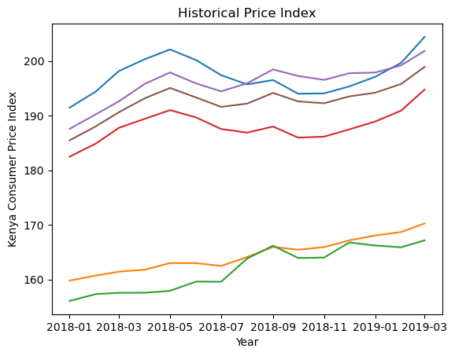

```python
#Data exploration

# Visualize the data
#plt.figure(figsize=(12, 6))
plt.plot(df)
plt.title('Historical Price Index')
plt.xlabel('Year')
plt.ylabel('Kenya Consumer Price Index')
plt.show()
```

- Basically since we want to predict the consumer price index over time, we would want to use dates as the dependent variable
- And the overall Kenya CPI as the independent variable which would use the dependent variable for generalization

```python
correlation=df.corr()
correlation['Kenya CPI'].sort_values(ascending=True)
```

```
Upper Income          0.671732
Lower  Income         0.780329
Middle Income         0.811479
Nairobi Combined      0.917577
CPI of Urban Areas    0.974351
Kenya CPI             1.000000
Name: Kenya CPI, dtype: float64
```

```python
#Data exploration

# Extract relevant columns of interest
#independent
df = df[['Kenya CPI']]
#depedent if and only if
#df = df[['Date']]
df.head()
```

| Date | Kenya CPI |
| --- | --- |
| 2018-01-01 | 185.47 |
| 2018-02-01 | 188.00 |
| 2018-03-01 | 190.62 |
| 2018-04-01 | 193.18 |
| 2018-05-01 | 195.05 |

```python
#look for missing values in our select column of interest
df.isna().sum()
#the first instance, it found nan values but after cleaning the data in excel the algorithmn run zero nan values
```

```
Kenya CPI    0
dtype: int64
```

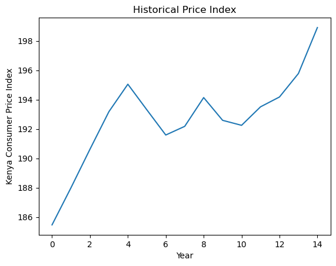

```python
plt.plot(data)
plt.title('Historical Price Index')
plt.xlabel('Year')
plt.ylabel('Kenya Consumer Price Index')
plt.show()
```

```python
# Normalize the data using Min-Max scaling
# Min-Max scaling is a technique for normalizing the data,
# ........which means transforming it in a way that the values fall within a specific range
# Sacaling ensures the data has a similar scale across features and that it falls within a range that is
# .......... suitable for the neural network to learn effectively.
scaler = MinMaxScaler()
data = scaler.fit_transform(data) # data defined above
```

```python
# standard basic RNN procedures

# EG Create sequences for training
# Sequences are essential for training RNNs because they can capture temporal dependencies in the data
sequence_length = 10  # You can adjust this value
X, y = [], []

# for loop ensures that you don't go out of bounds when creating sequences.
for i in range(len(data) - sequence_length):
    X.append(data[i:i+sequence_length])
    y.append(data[i+sequence_length])

X = np.array(X)
y = np.array(y)
```

```python
# Split the data into training and testing sets
# Recognize we are using 80% for training and 20 for testing
X_train, X_test, y_train, y_test = train_test_split(X, y, test_size=0.2, shuffle=False)
```

```python
# Build the Long Short-Term Memory (LSTM) model
# example of a simple RNN model using the Long Short-Term Memory (LSTM) architecture
model = keras.Sequential([
    keras.layers.LSTM(50, activation='relu', input_shape=(sequence_length, 1)),
    keras.layers.Dense(1)
])
#We can also try SGD or RMSprop in place of adam or vise versa.
#Basically these concepts adapts the learning rate during training to improve convergence
model.compile(optimizer='adam', loss='mean_squared_error')
```